# Week 5. Dimensionality reduction techniques

## Preparations

```r
# Set working directory
#setwd("Z:/Jatko-opinnot/IODS/IODS-project-1")
setwd("C:/Users/sirja/Documents/IODS-project-1")

# Access needed libraries
library("tidyverse")
library("GGally")
library("FactoMineR")
```

```r
# load the data
human <- read.csv("data/human.csv", row.names = 1)

# explore the dataset
str(human)
```

```
## 'data.frame':    155 obs. of  8 variables:
##  $ EduRatio   : num  1.007 0.997 0.983 0.989 0.969 ...
##  $ LabourRatio: num  0.891 0.819 0.825 0.884 0.829 ...
##  $ ExpEdu     : num  17.5 20.2 15.8 18.7 17.9 16.5 18.6 16.5 15.9 19.2 ...
##  $ LifeExp    : num  81.6 82.4 83 80.2 81.6 80.9 80.9 79.1 82 81.8 ...
##  $ GNI        : int  64992 42261 56431 44025 45435 43919 39568 52947 42155 32689 ...
##  $ MatMort    : int  4 6 6 5 6 7 9 28 11 8 ...
##  $ AdolBirth  : num  7.8 12.1 1.9 5.1 6.2 3.8 8.2 31 14.5 25.3 ...
##  $ ParlRep    : num  39.6 30.5 28.5 38 36.9 36.9 19.9 19.4 28.2 31.4 ...
```

## Task 1: Overview of the data

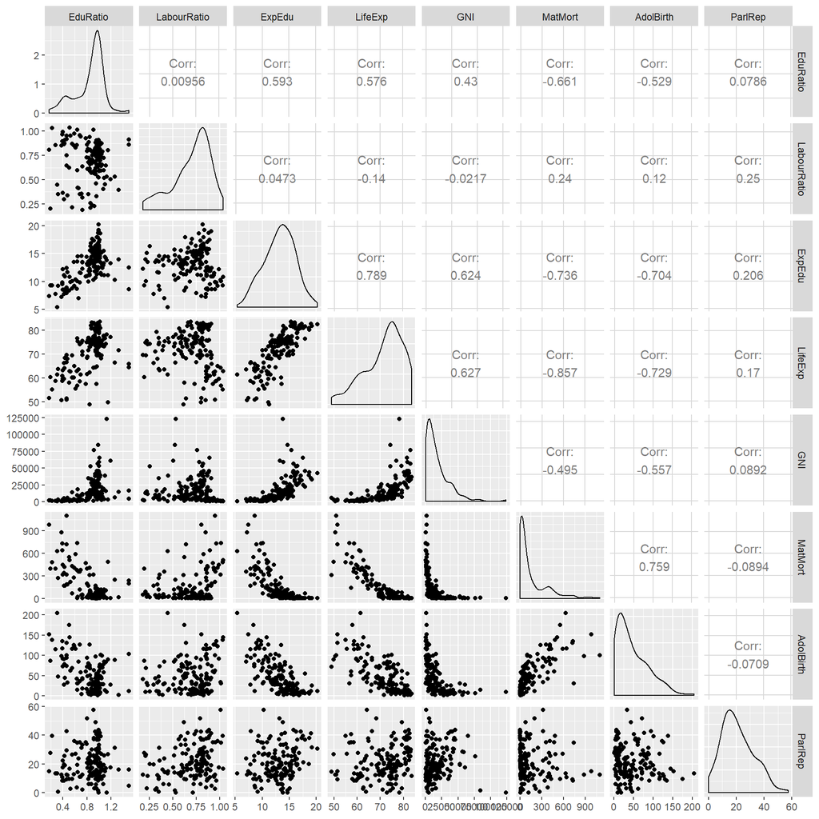

```r
ggpairs(human)
```

```r
summary(human)
```

```
##     EduRatio       LabourRatio         ExpEdu         LifeExp
##  Min.   :0.1717   Min.   :0.1857   Min.   : 5.40   Min.   :49.00
##  1st Qu.:0.7264   1st Qu.:0.5984   1st Qu.:11.25   1st Qu.:66.30
##  Median :0.9375   Median :0.7535   Median :13.50   Median :74.20
##  Mean   :0.8529   Mean   :0.7074   Mean   :13.18   Mean   :71.65
##  3rd Qu.:0.9968   3rd Qu.:0.8535   3rd Qu.:15.20   3rd Qu.:77.25
##  Max.   :1.4967   Max.   :1.0380   Max.   :20.20   Max.   :83.50
##       GNI            MatMort         AdolBirth         ParlRep
##  Min.   :   581   Min.   :   1.0   Min.   :  0.60   Min.   : 0.00
##  1st Qu.:  4198   1st Qu.:  11.5   1st Qu.: 12.65   1st Qu.:12.40
##  Median : 12040   Median :  49.0   Median : 33.60   Median :19.30
##  Mean   : 17628   Mean   : 149.1   Mean   : 47.16   Mean   :20.91
##  3rd Qu.: 24512   3rd Qu.: 190.0   3rd Qu.: 71.95   3rd Qu.:27.95
##  Max.   :123124   Max.   :1100.0   Max.   :204.80   Max.   :57.50
```

Most variables seem to be quite normally distributed. GNI, maternal mortality and adolescent birth rate are skewed. Many variables correlate. For example expected education and life expectancy have strong positive correlation, wheras maternal mortality life expectancy have strong negative correlation.

## Task 2: Principal component analysis

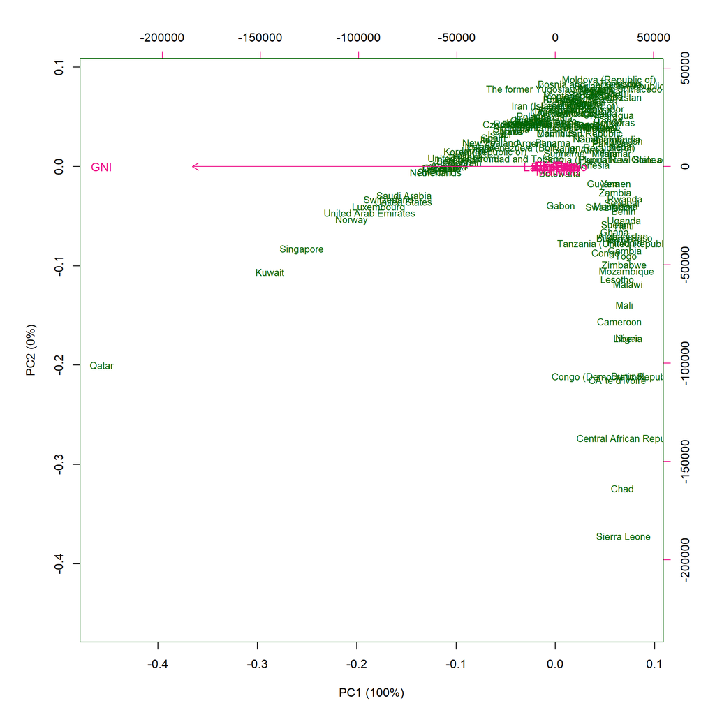

```r
# perform PCA
pca_human <- prcomp(human)
s <-summary(pca_human)
pca_pr <- round(100*s$importance[2, ], digits = 1)
pc_lab <- paste0(names(pca_pr), " (", pca_pr, "%)")

# draw a biplot
biplot(pca_human, cex = c(0.8, 1), col = c("darkgreen", "deeppink2"), xlab = pc_lab[1], ylab = pc_lab[2])
```

The figure looks strange because GNI has so much bigger variance than other variables. That’s why GNI explains 100% of variation here. Standardizing the data can solve the problem.

## Tasks 3 & 4: PCA with standardized data

```r
human_scaled <- scale(human)
pca_human <- prcomp(human_scaled)
s <- summary(pca_human)
pca_pr <- round(100*s$importance[2, ], digits = 1)
pca_pr
```

```
##  PC1  PC2  PC3  PC4  PC5  PC6  PC7  PC8
## 53.6 16.2  9.6  7.6  5.5  3.6  2.6  1.3
```

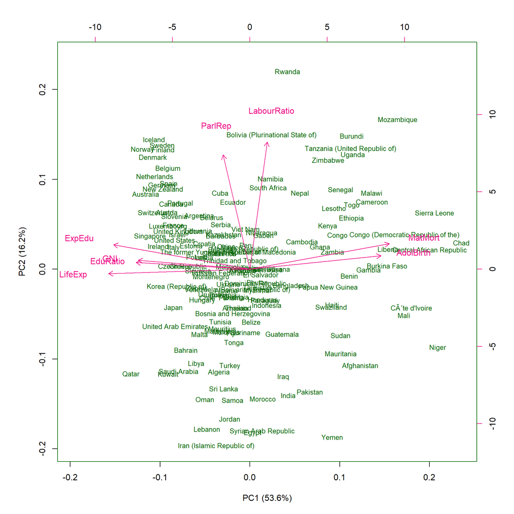

```r
pc_lab <- paste0(names(pca_pr), " (", pca_pr, "%)")
biplot(pca_human, cex = c(0.8, 1), col = c("darkgreen", "deeppink2"), xlab = pc_lab[1], ylab = pc_lab[2])
```